# Bank Marketing Prediction with Classification Model

Tito Krisnawati

2024-07-25

# Introduction

## Our Purpose

Data `bank-full.csv` merupakan data mengenai telemarketing dari sebuah bank di Portugal. Data `bank-full.csv` dapat dilihat diambil dari link berikut ini : https://archive.ics.uci.edu/dataset/222/bank+marketing

Pada kesempatan kali ini, saya akan menggunakan data tersebut untuk dapat memprediksi calon nasabah mana yang akan membeli product ketika di telepon oleh pihak bank.

## Preparation

Kita panggil setiap library yang dibutuhkan dalam proses pembuatan model klasifikasi hingga evaluasi dan hasil interpretasi model nantinya.

```r
# untuk persiapan data
library(dplyr)

# untuk text processing
library(tm)
library(SnowballC)
library(inspectdf)

# untuk keperluan machine learning
library(e1071)
library(caret)
library(ROCR)
library(caret)
library(rsample)

library(partykit)
library(randomForest)
```

# Data Preparation

## Read Dataset

Kita mulai dengan membaca dataset `bank-full.csv` dan kita simpan dalam variabel `bank`. Kemudian untuk mempersingkat pre-processing data, kita langsung ubah setiap variabel dengan tipe data `character` menjadi tipe data `factor` dengan menggunakan parameter `stringsAsFactors = TRUE`

```r
bank <- read.csv("bank-full.csv", sep = ";", stringsAsFactors = T)
head(bank)
```

|  | age | job | marital | education | default | balance | housing | loan | contact | day | month | duration | campaign | pdays | previous | poutcome | y |
| --- | --- | --- | --- | --- | --- | --- | --- | --- | --- | --- | --- | --- | --- | --- | --- | --- | --- |
| 1 | 58 | management | married | tertiary | no | 2143 | yes | no | unknown | 5 | may | 261 | 1 | -1 | 0 | unknown | no |
| 2 | 44 | technician | single | secondary | no | 29 | yes | no | unknown | 5 | may | 151 | 1 | -1 | 0 | unknown | no |
| 3 | 33 | entrepreneur | married | secondary | no | 2 | yes | yes | unknown | 5 | may | 76 | 1 | -1 | 0 | unknown | no |
| 4 | 47 | blue-collar | married | unknown | no | 1506 | yes | no | unknown | 5 | may | 92 | 1 | -1 | 0 | unknown | no |
| 5 | 33 | unknown | single | unknown | no | 1 | no | no | unknown | 5 | may | 198 | 1 | -1 | 0 | unknown | no |
| 6 | 35 | management | married | tertiary | no | 231 | yes | no | unknown | 5 | may | 139 | 1 | -1 | 0 | unknown | no |

Kita lihat tipe data dari setiap variabel-variabel dari data kita.

```r
glimpse(bank)
```

```
#> Rows: 45,211
#> Columns: 17
#> $ age       <int> 58, 44, 33, 47, 33, 35, 28, 42, 58, 43, 41, 29, 53, 58, 57, …
#> $ job       <fct> management, technician, entrepreneur, blue-collar, unknown, …
#> $ marital   <fct> married, single, married, married, single, married, single, …
#> $ education <fct> tertiary, secondary, secondary, unknown, unknown, tertiary, …
#> $ default   <fct> no, no, no, no, no, no, no, yes, no, no, no, no, no, no, no,…
#> $ balance   <int> 2143, 29, 2, 1506, 1, 231, 447, 2, 121, 593, 270, 390, 6, 71…
#> $ housing   <fct> yes, yes, yes, yes, no, yes, yes, yes, yes, yes, yes, yes, y…
#> $ loan      <fct> no, no, yes, no, no, no, yes, no, no, no, no, no, no, no, no…
#> $ contact   <fct> unknown, unknown, unknown, unknown, unknown, unknown, unknow…
#> $ day       <int> 5, 5, 5, 5, 5, 5, 5, 5, 5, 5, 5, 5, 5, 5, 5, 5, 5, 5, 5, 5, …
#> $ month     <fct> may, may, may, may, may, may, may, may, may, may, may, may, …
#> $ duration  <int> 261, 151, 76, 92, 198, 139, 217, 380, 50, 55, 222, 137, 517,…
#> $ campaign  <int> 1, 1, 1, 1, 1, 1, 1, 1, 1, 1, 1, 1, 1, 1, 1, 1, 1, 1, 1, 1, …
#> $ pdays     <int> -1, -1, -1, -1, -1, -1, -1, -1, -1, -1, -1, -1, -1, -1, -1, …
#> $ previous  <int> 0, 0, 0, 0, 0, 0, 0, 0, 0, 0, 0, 0, 0, 0, 0, 0, 0, 0, 0, 0, …
#> $ poutcome  <fct> unknown, unknown, unknown, unknown, unknown, unknown, unknow…
#> $ y         <fct> no, no, no, no, no, no, no, no, no, no, no, no, no, no, no, …
```

Berdasarkan investigasi di atas, data marketing bank memiliki 45.211 observasi dan 17 variabel. Berikut adalah deskripsi detail dari setiap kolom:

- `age` : usia nasabah (dalam tahun)
- `job`: jenis pekerjaan nasabah (categorical: “admin”, “unknown”, “unemployed”, “management”, “housemaid”, “entrepreneur”, “student”, “blue-collar”, “self-employed”, “retired”, “technician”, “services”)
- `marital`: status pernikahan nasabah (categorical: “married”, “divorced”, “single”)
- `education`: pendidikan nasabah (categorical: “unknown”, “secondary”, “primary”, “tertiary”)
- `default`: apakah memiliki kredit? (**yes** atau **no**)
- `balance`: rata-rata saldo tahunan nasabah (dalam euro)
- `housing`: memiliki kredit / pinjaman untuk rumah (**yes** atau **no**)
- `loan`: memiliki pinjaman pribadi / personal loan (**yes** atau **no**)
- `contact`: jenis alat komunikasi / kontak (categorical: “unknown”, “telephone”, “cellular”)
- `day`: hari terakhir di hubungi dalam bulan ini
- `month`: bulan terakhir dihubungi dalam tahun ini
- `duration`: lama durasi saat terakhir dihubungi (dalam satuan detik)
- `campaign`: berapa kali banyaknya nasabah dihubungi dalam menwarkan produk ini untuk klien tersebut (termasuk kontak terakhir)
- `pdays`: jumlah hari yang berlalu sejak nasabah terakhir dihubungi untuk penawaran produk (-1 berarti nasabah belum pernah dihubungi sebelumnya)
- `previous`: jumlah kontak yang dilakukan sebelum penawaran produk ini dan untuk nasabah ini
- `poutcome`: hasil dari penawaran produk / pemasaran sebelumnya (categorical: “unknown”, “other”, “failure”, “success”)
- `y` : apakah nasabah setuju dengan penawaran produk bank ini (dalam case ini deposito)? (**yes** atau **no**)

## Data Wrangling

Kita mencoba untuk melihat persebaran data dari setiap variabel pada data tersebut.

```r
summary(bank)
```

```
#>       age                 job           marital          education
#>  Min.   :18.00   blue-collar:9732   divorced: 5207   primary  : 6851
#>  1st Qu.:33.00   management :9458   married :27214   secondary:23202
#>  Median :39.00   technician :7597   single  :12790   tertiary :13301
#>  Mean   :40.94   admin.     :5171                    unknown  : 1857
#>  3rd Qu.:48.00   services   :4154
#>  Max.   :95.00   retired    :2264
#>                  (Other)    :6835
#>  default        balance       housing      loan            contact
#>  no :44396   Min.   : -8019   no :20081   no :37967   cellular :29285
#>  yes:  815   1st Qu.:    72   yes:25130   yes: 7244   telephone: 2906
#>              Median :   448                           unknown  :13020
#>              Mean   :  1362
#>              3rd Qu.:  1428
#>              Max.   :102127
#>
#>       day            month          duration         campaign
#>  Min.   : 1.00   may    :13766   Min.   :   0.0   Min.   : 1.000
#>  1st Qu.: 8.00   jul    : 6895   1st Qu.: 103.0   1st Qu.: 1.000
#>  Median :16.00   aug    : 6247   Median : 180.0   Median : 2.000
#>  Mean   :15.81   jun    : 5341   Mean   : 258.2   Mean   : 2.764
#>  3rd Qu.:21.00   nov    : 3970   3rd Qu.: 319.0   3rd Qu.: 3.000
#>  Max.   :31.00   apr    : 2932   Max.   :4918.0   Max.   :63.000
#>                  (Other): 6060
#>      pdays          previous           poutcome       y
#>  Min.   : -1.0   Min.   :  0.0000   failure: 4901   no :39922
#>  1st Qu.: -1.0   1st Qu.:  0.0000   other  : 1840   yes: 5289
#>  Median : -1.0   Median :  0.0000   success: 1511
#>  Mean   : 40.2   Mean   :  0.5803   unknown:36959
#>  3rd Qu.: -1.0   3rd Qu.:  0.0000
#>  Max.   :871.0   Max.   :275.0000
#>
```

# Cross-Validation

Sebelum kita membuat model, kita harus membagi dataset menjadi data train dan test. Kita bagi data dengan proporsi 80% train dan 20% test menggunakan fungsi `sample()`, `set.seed(100)`, dan simpan ke dalam obyek `data_train` dan `data_test`.

```r
RNGkind(sample.kind = "Rounding")
set.seed(100)
split_bank <- sample(nrow(bank), nrow(bank)*0.80)
data_train <- bank[split_bank, ]
data_test <- bank[-split_bank, ]
```

Kita lihat proporsi kelas target pada data train untuk memastikan apakah data train memiliki proporsi kelas target yang seimbang.

> Yang menjadi variabel target kita adalah `y`, yaitu apakah nasabah setuju dengan penawaran produk bank ini (dalam case ini deposito)?

```r
prop.table(table(data_train$y))
```

```
#>
#>        no       yes
#> 0.8828799 0.1171201
```

Berdasarkan proporsi di atas, dapat disimpulkan bahwa **proporsi kelas target tidak seimbang**

Jadi, kita harus menyeimbangkannya sebelum menggunakannya pada model kita. Kita akan menggunakan metode *downsampling* pada `data_train` menggunakan fungsi `downSample()`, lalu kita simpan data hasil downsample dalam objek `data_train_down`.

```r
set.seed(100)
data_train_down <- downSample(
  x = data_train %>% select(-y),
  y = data_train$y,
  yname = "y"
)

head(data_train_down)
```

|  | age | job | marital | education | default | balance | housing | loan | contact | day | month | duration | campaign | pdays | previous | poutcome | y |
| --- | --- | --- | --- | --- | --- | --- | --- | --- | --- | --- | --- | --- | --- | --- | --- | --- | --- |
| 1 | 31 | management | single | tertiary | no | 713 | no | no | cellular | 28 | aug | 162 | 1 | -1 | 0 | unknown | no |
| 2 | 31 | admin. | divorced | secondary | no | 47 | yes | no | unknown | 19 | may | 34 | 9 | -1 | 0 | unknown | no |
| 3 | 53 | retired | divorced | tertiary | no | 599 | yes | no | unknown | 13 | may | 322 | 3 | -1 | 0 | unknown | no |
| 4 | 34 | blue-collar | married | secondary | no | 837 | yes | yes | cellular | 13 | apr | 495 | 1 | -1 | 0 | unknown | no |
| 5 | 34 | blue-collar | married | secondary | no | 932 | no | yes | cellular | 18 | nov | 148 | 2 | 132 | 1 | other | no |
| 6 | 48 | blue-collar | married | secondary | no | 1791 | no | no | cellular | 7 | aug | 63 | 2 | -1 | 0 | unknown | no |

Kita lihat sekarang proporsi kelas target kita pada data train kita yang baru yaitu `data_train_down`

```r
prop.table(table(data_train_down$y))
```

```
#>
#>  no yes
#> 0.5 0.5
```

Berdasarkan proporsi di atas, dapat disimpulkan bahwa **proporsi kelas target sudah seimbang**

> Jadi, untuk tahapan selanjutnya, kita akan menggunakan `data_train_down` untuk pembuatan model Naive Bayes, Decision Tree, dan Random Forest.

# Naive Bayes

Setelah membagi data menjadi data train dan test serta melakukan downsample pada data train, kita akan membuat model pertama dengan algoritma Naive Bayes.

```r
model_naive <- naiveBayes(
  formula = y ~ .,
  data = data_train_down,
  laplace = 1
)

model_naive
```

```
#>
#> Naive Bayes Classifier for Discrete Predictors
#>
#> Call:
#> naiveBayes.default(x = X, y = Y, laplace = laplace)
#>
#> A-priori probabilities:
#> Y
#>  no yes
#> 0.5 0.5
#>
#> Conditional probabilities:
#>      age
#> Y         [,1]     [,2]
#>   no  40.61284 10.03323
#>   yes 41.66667 13.57682
#>
#>      job
#> Y          admin. blue-collar entrepreneur   housemaid  management     retired
#>   no  0.113935970 0.224105461  0.040489642 0.030838041 0.209039548 0.041431262
#>   yes 0.121704331 0.135122411  0.022598870 0.019303202 0.243644068 0.099340866
#>      job
#> Y     self-employed    services     student  technician  unemployed     unknown
#>   no    0.029425612 0.090866290 0.015301318 0.173022599 0.027542373 0.004001883
#>   yes   0.035781544 0.069915254 0.049435028 0.158662900 0.038370998 0.006120527
#>
#>      marital
#> Y      divorced   married    single
#>   no  0.1255013 0.5925926 0.2819061
#>   yes 0.1167728 0.5265393 0.3566879
#>
#>      education
#> Y        primary  secondary   tertiary    unknown
#>   no  0.15731132 0.51816038 0.28396226 0.04056604
#>   yes 0.10872642 0.46603774 0.37806604 0.04716981
#>
#>      default
#> Y              no         yes
#>   no  0.981595092 0.018404908
#>   yes 0.990089665 0.009910335
```

[output cut: 44 more lines]

```
#>
#>      pdays
#> Y         [,1]      [,2]
#>   no  36.68343  97.28088
#>   yes 66.49315 116.13519
#>
#>      previous
#> Y          [,1]     [,2]
#>   no  0.5889991 4.639023
#>   yes 1.1602927 2.556477
#>
#>      poutcome
#> Y        failure      other    success    unknown
#>   no  0.10660377 0.04221698 0.01179245 0.83938679
#>   yes 0.11415094 0.05683962 0.18490566 0.64410377
```

## Prediksi Naive Bayes

Kita akan melakukan prediksi ke data test menggunakan `model_naive`. Kita menggunakan fungsi `predict()` dengan parameter `type = "class"` untuk mendapatkan prediksi kelas. Kemudian kita menyimpan hasil prediksi ke dalam objek `pred_naive`.

```r
# your code here
pred_naive <- predict(
  object = model_naive,
  newdata = data_test,
  type = "class"
)
```

## Evaluasi Model Naive Bayes

Bagian terakhir, kita melakukan evaluasi model. Kita dapat memeriksa performa model Naive Bayes menggunakan `confusionMatrix()` dan membandingkan kelas hasil prediksi (`pred_naive`) dengan label sebenarnya dari `data_test`. Kita set status nasabah yang mengambil produk (deposito) yang telah ditawarkan sebagai kelas positif (`positive = "yes"`).

```r
confusionMatrix(
  data = pred_naive,
  reference = data_test$y,
  positive = "yes",
  mode = "everything"
)
```

```
#> Confusion Matrix and Statistics
#>
#>           Reference
#> Prediction   no  yes
#>        no  5659  159
#>        yes 2331  894
#>
#>                Accuracy : 0.7246
#>                  95% CI : (0.7153, 0.7338)
#>     No Information Rate : 0.8836
#>     P-Value [Acc > NIR] : 1
#>
#>                   Kappa : 0.294
#>
#>  Mcnemar's Test P-Value : <0.0000000000000002
#>
#>             Sensitivity : 0.84900
#>             Specificity : 0.70826
#>          Pos Pred Value : 0.27721
#>          Neg Pred Value : 0.97267
#>               Precision : 0.27721
#>                  Recall : 0.84900
#>                      F1 : 0.41795
#>              Prevalence : 0.11644
#>          Detection Rate : 0.09886
#>    Detection Prevalence : 0.35663
#>       Balanced Accuracy : 0.77863
#>
#>        'Positive' Class : yes
#>
```

# Decision Tree

Sekarang, mari kita buat model **Decision Tree** menggunakan fungsi `ctree()` dan simpan ke dalam objek `model_dt`. Untuk melakukan *tuning* model, mari kita atur parameter `mincriterion = 0.95`.

```r
set.seed(100)
model_dt <- ctree(formula = y ~ .,
                  data = data_train_down,
                  control = ctree_control(mincriterion = 0.95))
```

Untuk mendapatkan penggambaran yang lebih baik tentang model, mari kita buat plot dari model dan gunakan parameter `type = "simple"`.

[figure not shown]

```r
# your code here
plot(model_dt, type = "simple")
```

## Prediksi Model Decision Tree

Setelah kita membuat model, coba lakukan prediksi ke data test berdasarkan `model_dt` menggunakan fungsi `predict()` dengan mengatur parameter `type = "response"`.

```r
# your code here
pred_dt <- predict(model_dt,
                   data_test,
                   type = "response")
```

## Evaluasi Model Decision Tree

Untuk memeriksa performa model, kita dapat menggunakan `confusionMatrix()`. Kita set status nasabah yang mengambil produk (deposito) yang telah ditawarkan sebagai kelas positif (`positive = "yes"`).

```r
# your code here
confusionMatrix(
  data = pred_dt,
  reference = data_test$y,
  positive = "yes",
  mode = "everything"
)
```

```
#> Confusion Matrix and Statistics
#>
#>           Reference
#> Prediction   no  yes
#>        no  6453  130
#>        yes 1537  923
#>
#>                Accuracy : 0.8157
#>                  95% CI : (0.8075, 0.8236)
#>     No Information Rate : 0.8836
#>     P-Value [Acc > NIR] : 1
#>
#>                   Kappa : 0.433
#>
#>  Mcnemar's Test P-Value : <0.0000000000000002
#>
#>             Sensitivity : 0.8765
#>             Specificity : 0.8076
#>          Pos Pred Value : 0.3752
#>          Neg Pred Value : 0.9803
#>               Precision : 0.3752
#>                  Recall : 0.8765
#>                      F1 : 0.5255
#>              Prevalence : 0.1164
#>          Detection Rate : 0.1021
#>    Detection Prevalence : 0.2720
#>       Balanced Accuracy : 0.8421
#>
#>        'Positive' Class : yes
#>
```

# Random Forest

Model terakhir yang akan kita buat adalah **Random Forest**.

Sekarang, kita akan coba eksplorasi model random forest yang dibuat dengan menggunakan *hyperparameter* di bawah ini:

- `set.seed(100)` # angka seed
- `number = 5` # jumlah k-fold cross-validation
- `repeats = 3` # jumlah iterasi

> Perintah di bawah ini di komen, agar ketika di-knit tidak perlu dijalankan kembali.

```r
#set.seed(100)
# # definisikan training control untuk repeated k-fold cross validation
# train_ctrl <- trainControl(method = "repeatedcv",
#                            number = 5, # seberapa banyak kita ingin membagi data
#                            repeats = 3)

# # training model random forest dengan train()
# bank_forest <- train(y ~ .,
#                    data = data_train_down,
#                    method = "rf", # pilih metode random forest
#                   trControl = train_ctrl)
```

Salah satu kelemahan random forest adalah pembuatan model yang membutuhkan waktu yang cukup lama. Practice yang baik selesai melakukan training adalah menyimpan model tersebut ke dalam bentuk file RDS dengan function `saveRDS()` agar model dapat langsung digunakan tanpa harus training dari awal. Jadi, agar bisa digunakan lebih cepat ke depannya, kita simpan model random forest yang telah kita buat tersebut yaitu `bank_forest` dalam sebuah file `model_rf.RDS`

> Perintah ini dikomen agar ketika di-knit tidak dijalankan kembali, karena model sudah dibentuk

```r
# menyimpan model ke format RDS
# saveRDS(bank_forest, "model_rf.RDS")
```

Untuk membaca model Random Forest yang sudah disimpan (`model_rf.RDS`), kita dapat menggunakan fungsi `readRDS()` dan simpan ke dalam objek `bank_forest`.

```r
bank_forest <- readRDS("model_rf.RDS")
```

Kemudian, lihatlah rangkuman final model dari model Random Forest menggunakan `bank_forest$finalModel`

```r
#library(randomForest)
# your code here
bank_forest$finalModel
```

```
#>
#> Call:
#>  randomForest(x = x, y = y, mtry = param$mtry)
#>                Type of random forest: classification
#>                      Number of trees: 500
#> No. of variables tried at each split: 22
#>
#>         OOB estimate of  error rate: 13.86%
#> Confusion matrix:
#>       no  yes class.error
#> no  3522  714   0.1685552
#> yes  460 3776   0.1085930
```

Dalam praktiknya, random forest telah memiliki estimasi out-of-bag (OOB) yang merepresentasikan akurasi pada *out-of-bag data* (data yang tidak diambil ketika sampling/tidak digunakan dalam pembuatan random forest).

Kita juga bisa menggunakan informasi *Variable Importance*, untuk mendapatkan daftar variabel penting yang digunakan pada model Random Forest. Banyak yang berargumen bahwa Random Forest, sebgai model *Black Box*, tidak dapat menawarkan informasi penting lain selain akurasinya yang amat tinggi. Namun, memberikan perhatian khusus pada atribut seperti *Variable Importance* sering kali membantu kita dalam mendapatkan informasi berharga tentang data.

Untuk menentukan variabel yang memiliki pengaruh penting dalam menghasilkan prediksi (*Variable Importance*), kita dapat menggunakan fungsi `varImp()`, kemudian kita masukkan ke dalam fungsi `plot()` untuk mendapatkan visualisasinya.

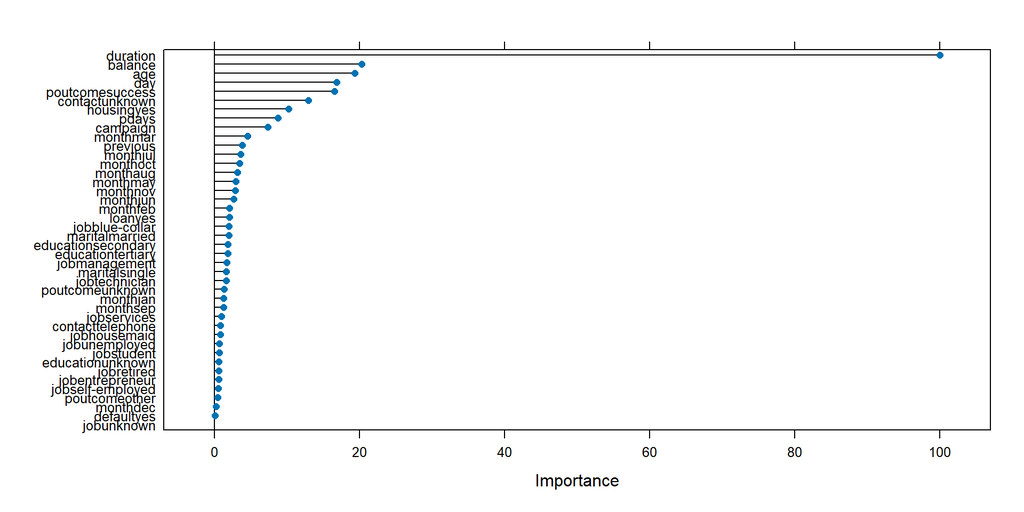

```r
# your code here
varImp(bank_forest) %>% plot()
```

## Prediksi Model Random Forest

Setelah membangun model, kini kita dapat memprediksi data test menggunakan `bank_forest`. Gunakan fungsi `predict()` dan atur parameter `type = "raw"` untuk mendapatkan prediksi kelas.

```r
# your code here
pred_rf <- predict(
  bank_forest,
  data_test,
  type = "raw"
)
```

## Evaluasi Model Random Forest

Selanjutnya, kita evaluasi model random forest dengan fungsi `confusionMatrix()`.

```r
# your code here
confusionMatrix(
  data = pred_rf,
  reference = data_test$y,
  positive = "yes",
  mode = "everything"
)
```

```
#> Confusion Matrix and Statistics
#>
#>           Reference
#> Prediction   no  yes
#>        no  6630  108
#>        yes 1360  945
#>
#>                Accuracy : 0.8377
#>                  95% CI : (0.8299, 0.8452)
#>     No Information Rate : 0.8836
#>     P-Value [Acc > NIR] : 1
#>
#>                   Kappa : 0.4797
#>
#>  Mcnemar's Test P-Value : <0.0000000000000002
#>
#>             Sensitivity : 0.8974
#>             Specificity : 0.8298
#>          Pos Pred Value : 0.4100
#>          Neg Pred Value : 0.9840
#>               Precision : 0.4100
#>                  Recall : 0.8974
#>                      F1 : 0.5628
#>              Prevalence : 0.1164
#>          Detection Rate : 0.1045
#>    Detection Prevalence : 0.2549
#>       Balanced Accuracy : 0.8636
#>
#>        'Positive' Class : yes
#>
```

Cara lain untuk mengevaluasi performa model adalah dengan melihat nilai ROC dan AUC-nya. Untuk menghitungnya, kita membutuhkan *probabilitas ke kelas positif untuk setiap observasi*. Mari fokus pada nilai ROC dan AUC dari prediksi model Random Forest. Pertama, lakukan prediksi ke data test menggunakan `bank_forest` dengan menggunakan parameter `type = "prob"`. Akan dihasilkan prediksi nilai probabilitas untuk setiap kelas. Anda dapat menyimpan hasil prediksi ke dalam objek `prob_test`.

```r
prob_test <- predict(bank_forest,
                     data_test,
                     type = "prob")

prob_test[,"yes"]
```

[output not shown]

[output cut: 739 more lines]

```r
pred_roc <- prediction(predictions = prob_test[,"yes"],
                       labels = data_test$y)
```

Selanjutnya, gunakan fungsi `performance()` dari package ROCR dengan mendefinisikan axis plot untuk menghasilkan plot ROC. Simpan hasilnya ke dalam objek `perf`. Untuk menggunakan fungsi `performance()`, atur parameter di bawah ini: - `prediction.obj = pred_roc` - `measure = "tpr"` - `x.measure = "fpr"`

```r
perf <- performance(pred_roc,
                    "tpr",
                    "fpr")
```

Setelah kita membuat objek `perf`, kita buat plot ROC dengan memasukkan objek `perf` ke dalam fungsi`plot()`.

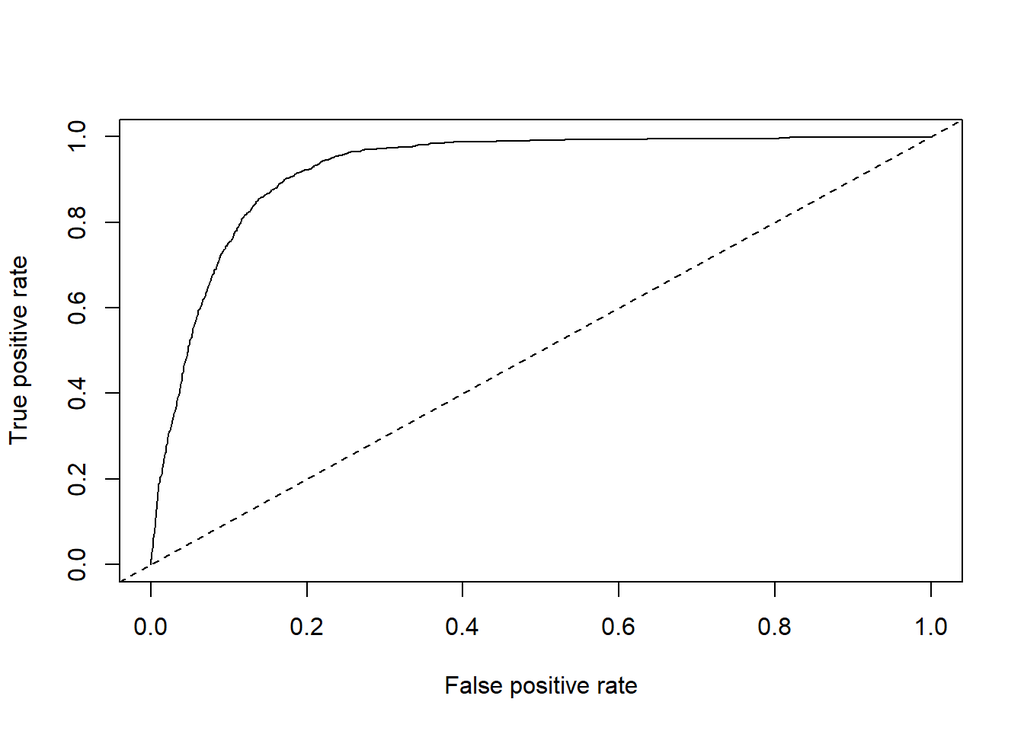

```r
plot(perf)
abline(0,1 , lty = 2)
```

Untuk melakukan evaluasi kurva ROC tersebut, kita lihat apakah ada hasil yang tidak diinginkan dari model. Selanjutnya, kita mencari nilai AUC menggunakan fungsi `performance()` dengan mengatur parameter `prediction.obj = pred_roc` dan `measure = "auc"` lalu simpan ke dalam objek `auc`.

```r
auc <- performance(pred_roc, "auc")
auc@y.values[[1]]
```

```
#> [1] 0.9246476
```

> Nilai AUC 92.46% berarti performa model baik dalam mengklasifikasikan kelas postif maupun kelas negatif

# Conclusion

Jika saya adalah seorang manager marketing di bank tersebut, dimana saya akan bertujuan untuk berusaha mendapatkan peluang sebesar-besarnya agar nasabah yang dihubungi oleh telemarketer saya menerima tawaran produk (deposito) yang kami tawarkan, maka saya akan memilih evaluasi **Recall / Sensitivity**. Hal ini juga terlihat dari ketiga model tersebut, nilai Recall jauh lebih tinggi dibandingkan dengan Presisi. Hal ini menunjukkan, data pada case ini memang cenderung mempertimbangkan evaluasi Recall.

> Dari ketiga model di atas, Decision Tree dan Random Forest memiliki nilai evaluasi model yang tidak jauh berbeda. Namun dari segi cost / komputasi pembuatan model, Random Forest sangat lama. Jadi saya lebih memilih model **Decision Tree** sebagai model terbaik dalam pemecahan case ini